# ANOVA F-test & pairwise comp

### **NOTES ON STATISTICS, PROBABILITY and MATHEMATICS**

### ANOVA Results Interpretation in R:

From [Statistics Make Me Cry](http://www.statsmakemecry.com/smmctheblog/stats-soup-anova-ancova-manova-mancova):

> An “Analysis of Variance” (ANOVA) tests three or more groups for mean differences based on a continuous (i.e. scale or interval) response variable (a.k.a. dependent variable). The term “factor” refers to the variable that distinguishes this group membership. Race, level of education, and treatment condition are examples of factors.

> There are two main types of ANOVA: (1) “one-way” ANOVA compares levels (i.e. groups) of a single factor based on single continuous response variable (e.g. comparing test score by ‘level of education’) and (2) a “two-way” ANOVA compares levels of two or more factors for mean differences on a single continuous response variable(e.g. comparing test score by both ‘level of education’ and ‘zodiac sign’). In practice, you will see one-way ANOVAs more often and when the term ANOVA is generically used, it often refers to a one-way ANOVA.

The essential computation is the F-test:

$$F=\frac{\text{variance between
treatments}}{\text{variance within
treatments}}=\large\frac{\frac{\text{Sum
Sqs}_{\text{treat'ts}}}{\text{no. treat'ts}-1}}{\frac{\text{Sum
Sqs}_{\text{err's}}}{\text{no. cases}-\text{no.
treat'ts}}}$$
,

Let’s create three normally distributed samples with the same variance, but different means, and run an anova in R:

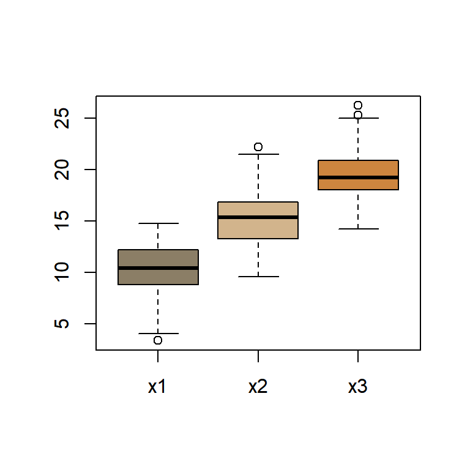

```r
set.seed(1); n = 50; x1 = rnorm(n, 10, 3); x2 = rnorm(n, 15, 3); x3 = rnorm(n, 20, 3)
dataframe = data.frame(x1,x2,x3)
boxplot(dataframe, col=c("wheat4", "tan", "tan3"))
```

Now let’s calculate the anova manually:

```r
datamatrix = as.matrix(dataframe)
(global.mean = mean(datamatrix))                                    # The overall mean
```

```
## [1] 15.06529
```

```r
(group.means = apply(datamatrix, 2, mean))                          # The respective means for each group
```

```
##       x1       x2       x3
## 10.30134 15.35198 19.54254
```

```r
(SST = sum((datamatrix - global.mean)^2))                           # Sum squares total
```

```
## [1] 3216.922
```

```r
(SSBetween = sum(nrow(datamatrix) * (group.means-global.mean)^2))   # Between groups
```

```
## [1] 2141.158
```

```r
(SSWithin = sum(scale(datamatrix, center = T, scale = F)^2))        # Sum Squares Residuals
```

```
## [1] 1075.764
```

```r
(MeanSqBetween = SSBetween / (ncol(datamatrix) - 1))                # Between/df(groups - 1) [3 - 1]
```

```
## [1] 1070.579
```

```r
(MeanSqWithin = SSWithin / (length(datamatrix) - ncol(datamatrix))) # Within/df(subjects - no.groups) [150-3]
```

```
## [1] 7.318123
```

```r
(F_value = MeanSqBetween / MeanSqWithin)                            # F value
```

```
## [1] 146.2915
```

Compare to the R function. First let’s ready up the data:

```r
datalong = stack(dataframe)
fit = aov(values ~ ind, datalong); summary(fit)
```

```
##              Df Sum Sq Mean Sq F value Pr(>F)
## ind           2   2141  1070.6   146.3 <2e-16 ***
## Residuals   147   1076     7.3
## ---
## Signif. codes:  0 '***' 0.001 '**' 0.01 '*' 0.05 '.' 0.1 ' ' 1
```

Alternatively we can resort to the OLS function:

```r
OLS = lm(values ~ ind, datalong); summary(OLS); anova(OLS)
```

```
##
## Call:
## lm(formula = values ~ ind, data = datalong)
##
## Residuals:
##     Min      1Q  Median      3Q     Max
## -6.9454 -1.5772 -0.1468  1.5970  6.8529
##
## Coefficients:
##             Estimate Std. Error t value Pr(>|t|)
## (Intercept)  10.3013     0.3826  26.926   <2e-16 ***
## indx2         5.0506     0.5410   9.335   <2e-16 ***
## indx3         9.2412     0.5410  17.080   <2e-16 ***
## ---
## Signif. codes:  0 '***' 0.001 '**' 0.01 '*' 0.05 '.' 0.1 ' ' 1
##
## Residual standard error: 2.705 on 147 degrees of freedom
## Multiple R-squared:  0.6656, Adjusted R-squared:  0.661
## F-statistic: 146.3 on 2 and 147 DF,  p-value: < 2.2e-16
```

```
## Analysis of Variance Table
##
## Response: values
##            Df Sum Sq Mean Sq F value    Pr(>F)
## ind         2 2141.2 1070.58  146.29 < 2.2e-16 ***
## Residuals 147 1075.8    7.32
## ---
## Signif. codes:  0 '***' 0.001 '**' 0.01 '*' 0.05 '.' 0.1 ' ' 1
```

#### Pairwise Comparisons:

Additional analyses are required after an omnibus test. The `function pairwise.t.test()` computes the pair-wise comparisons between group means with corrections for multiple testing:

`pairwise.t.test(reponse, factor, p.adjust = method, alternative = c("two.sided", "less", "greater"))`

**Response** is a vector of observations (the response variable), **factor** a list of factors and **p.adjust** is the correction method (e.g., “Bonferroni”).

```r
options(scipen=999)
pairwise.t.test(datalong$values, datalong$ind, p.adjust="bonferroni")
```

```
##
##  Pairwise comparisons using t tests with pooled SD
##
## data:  datalong$values and datalong$ind
##
##    x1                   x2
## x2 0.00000000000000044  -
## x3 < 0.0000000000000002 0.00000000000428679
##
## P value adjustment method: bonferroni
```

All the pairwise comparisons are statistically significant.

Alternatively, a Tukey test can be undertaken:

```r
TukeyHSD(fit)
```

```
##   Tukey multiple comparisons of means
##     95% family-wise confidence level
##
## Fit: aov(formula = values ~ ind, data = datalong)
##
## $ind
##           diff      lwr       upr p adj
## x2-x1 5.050635 3.769616  6.331653     0
## x3-x1 9.241199 7.960181 10.522217     0
## x3-x2 4.190564 2.909546  5.471583     0
```

The differences pairwise and the p-values are shown.

[Home Page](http://rinterested.github.io/statistics/index.html)

**NOTE: These are tentative notes on different topics for personal use - expect mistakes and misunderstandings.**